# Final project

Mandi, Marielena, Amy

### Description of the dataset and research questions

We will be using data from a study conducted in 2020 called ACT Suicide Prevention. This study collected dozens of variables of data, including responses to various assessments, such as the Beck Depression Inventory, from participants to determine if the ACT intervention for suicidality in college students was effective. Among the many variables gathered were participants’ age, living situation, race/ethnicity, gender, household income, and financial support. We are interested in looking at the relationship between college-aged female-identifying participants, household income, and levels of depression. Utilizing these four variables, gender, age, income, and severity of depression, we will be able to develop several visual graphs to help interpret the data and the relationships between variables, if any. Depending on our preliminary findings, we may decide to reduce or expand the variables we include in our project, as there are several available in the dataset.. Although there are no personal identifiers in the dataset, it is very personal information that has been gathered from participants. So we may need to “scramble” data for analysis and our final presentation. Our research question for this project will be “Is there a relationship between income rates in college-aged women and depression?” Variables of interest:

- Age (dem 1.01)
- Gender (dem1.07a - demo1.07b)
- Income:
  - Household income (dem1.13)
  - Income/job situation (dem1.14 - dem1.15b)
  - Financial support (dem1.16a - dem1.16g)
- Beck Depression Inventory (bdi1)

### Draft Data Script

#### Load in data

```r
act_t1 <- import(here("data", "ACT Suicide Prevention T1.sav"), setclass = "tbl_df") %>%
  characterize() %>%
  clean_names()
```

```r
act_t1 <- import(here("data", "ACT Suicide Prevention T1.sav"), setclass = "tbl_df") %>%
  characterize() %>%
  clean_names()

act_t1_12520 <- import(here("data", "ACT Suicide Prevention T1 1-25-20.sav"), setclass = "tbl_df") %>%
  characterize() %>%
  clean_names()
```

#### Conduct a full join to explore the differences in the two files shared with us. Both datasets had the same number of rows (one row per participant as confirmed using the `length()` and `unique()` functions), but one dataset had 137 columns and the other had 161 columns. We suspected the file with more columns contained additional variables. The joined file had no change in number of rows and 161 columns.

```r
dim(act_t1)
```

```
## [1] 972 137
```

```r
dim(act_t1_12520)
```

```
## [1] 972 161
```

```r
length(unique(act_t1$id))
```

```
## [1] 972
```

```r
length(unique(act_t1_12520$id))
```

```
## [1] 972
```

```r
act_all <- full_join(act_t1, act_t1_12520)

dim(act_all)
```

```
## [1] 972 161
```

```r
length(unique(act_all$id))
```

```
## [1] 972
```

### Used select to pull out all columns with demographic infomation as well as BDI scores as these were the only variables we were intersted in looking at. From here we were able to pick which specific variables we wanted to look at relationships between.

```r
act_all %>%
  select(starts_with("dem1"), bdi1
    )
```

```
## # A tibble: 972 × 68
##    dem1_01 dem1_02a   dem1_02b    dem1_02c   dem1_03a dem1_03b dem1_03c dem1_04
##    <chr>   <chr>      <chr>       <chr>      <chr>    <chr>       <dbl> <chr>
##  1 18 yrs  In a dorm  In a dorm … <NA>       Yes      ""             NA Not His…
##  2 19 yrs  In an apa… <NA>        With your… Yes      ""             NA Not His…
##  3 18 yrs  In an apa… <NA>        With your… Yes      ""             NA Not His…
##  4 18 yrs  In a dorm  In a dorm … <NA>       Yes      ""             NA Hispani…
##  5 18 yrs  In an apa… <NA>        With your… Yes      ""             NA Hispani…
##  6 18 yrs  In an apa… <NA>        In an apa… Yes      ""             NA Not His…
##  7 18 yrs  In an apa… <NA>        With your… Yes      ""             NA Not His…
##  8 19 yrs  In a dorm  In a dorm … <NA>       Yes      ""             NA Not His…
##  9 18 yrs  In a dorm  In a dorm … <NA>       Yes      ""             NA Not His…
## 10 18 yrs  In an apa… <NA>        With your… Yes      ""             NA Not His…
## # … with 962 more rows, and 60 more variables: dem1_05a <chr>, dem1_05b <chr>,
## #   dem1_05c <chr>, dem1_05d <chr>, dem1_05e <chr>, dem1_05f <chr>,
## #   dem1_05g <chr>, dem1_05h <chr>, dem1_06 <chr>, dem1_07a <chr>,
## #   dem1_07b <chr>, dem1_08a <chr>, dem1_08b <chr>, dem1_08c <chr>,
## #   dem1_09a <chr>, dem1_09b <chr>, dem1_09c <chr>, dem1_10 <chr>,
## #   dem1_11a <chr>, dem1_11b <chr>, dem1_12a <chr>, dem1_12b <chr>,
## #   dem1_13 <chr>, dem1_14 <chr>, dem1_15a <chr>, dem1_15b <chr>, …
```

#### Calculate *M*, *SD*, *n*, min, and max of Beck Depression Inventory (BDI) scores by all reported genders.

```r
act_all %>%
  group_by(dem1_07a) %>%
  summarize(mean_bdi = mean(bdi1, na.rm = TRUE),
            sd_bdi = sd(bdi1, na.rm = TRUE),
            n_bdi = n(),
            min_bdi = min(bdi1, na.rm = TRUE),
            max_bdi = max(bdi1, na.rm = TRUE))
```

```
## # A tibble: 3 × 6
##   dem1_07a    mean_bdi sd_bdi n_bdi min_bdi max_bdi
##   <chr>          <dbl>  <dbl> <int>   <dbl>   <dbl>
## 1 Man             6.86   7.16   369       0      53
## 2 Transgender    21     NA        1      21      21
## 3 Woman           8.16   6.86   602       0      36
```

#### Calculate *M*, *SD*, and *n* of Beck Depression Inventory (BDI) scores by all reported genders and income level. This resulted in a table with columns for gender, income category, and descriptive stats for each group (rows corresponded to stats for a gender group and income group). We used `pivot_wider()` to widen the table by the gender variable. This resulted in *M*, *SD*, and *n* columns for each gender. However, the resulting columns were not grouped by gender but by descriptive stat (e.g., mean_bdi_Man,mean_bdi_Transgender, mean_bdi_Woman). We wanted the descriptives (*M*, *SD*, and *n*) grouped by gender (e.g., *M*, *SD*, *n* for men, etc.). To accomplish this, we used `pivot_wider_spec()` to summarize BDI descriptive stats for each income category by reported gender. In other words, the resulting table has sets of columns of descriptives for each reported gender and one row per income category. We then used `pivot_longer()` to transform the table to a long form.

```r
act_all_descrip_gender_income <- act_all %>%
  mutate(dem1_14 = factor(dem1_14, levels = c("Less than $5,000",
                                              "$5,000 - $9,999",
                                              "$10,000 - $14,999",
                                              "$15,000 - $19,999",
                                              "$20,000 - $24,999",
                                              "$25,000 - $29,999",
                                              "$50,000 or more",
                                              "I choose not to answer",
                                              "Unknown"
                                              )) )%>%
  group_by(dem1_07a, dem1_14) %>%
  summarize(mean_bdi = mean(bdi1, na.rm = TRUE),
            sd_bdi = sd(bdi1, na.rm = TRUE),
            n_bdi = n())

act_all_descrip_gender_income
```

```
## # A tibble: 18 × 5
## # Groups:   dem1_07a [3]
##    dem1_07a    dem1_14                mean_bdi sd_bdi n_bdi
##    <chr>       <fct>                     <dbl>  <dbl> <int>
##  1 Man         Less than $5,000           6.72  6.53    235
##  2 Man         $5,000 - $9,999            6.95  7.92     55
##  3 Man         $10,000 - $14,999          6.71  7.24     14
##  4 Man         $15,000 - $19,999          8    NA         1
##  5 Man         $50,000 or more           15.3  19.6       3
##  6 Man         I choose not to answer    10.5   4.51      4
##  7 Man         Unknown                    6.64  8.20     56
##  8 Man         <NA>                       8    NA         1
##  9 Transgender Less than $5,000          21    NA         1
## 10 Woman       Less than $5,000           8.04  6.85    360
## 11 Woman       $5,000 - $9,999            8.38  6.64     66
## 12 Woman       $10,000 - $14,999          9.62  8.89     21
## 13 Woman       $15,000 - $19,999         11.5   0.707     2
## 14 Woman       $20,000 - $24,999          5    NA         1
## 15 Woman       $25,000 - $29,999          4    NA         1
## 16 Woman       $50,000 or more           10.5  11.7       4
## 17 Woman       I choose not to answer     9.22  9.16      9
## 18 Woman       Unknown                    8.03  6.49    138
```

```r
act_all_descrip_gender_income_wide <- act_all_descrip_gender_income %>%
  pivot_wider(
    names_from = dem1_07a,
    values_from = c(mean_bdi, sd_bdi, n_bdi)
    ) %>%
  arrange(dem1_14)

act_all_descrip_gender_income_wide
```

```
## # A tibble: 10 × 10
##    dem1_14                mean_bdi_Man mean_bdi_Transg… mean_bdi_Woman sd_bdi_Man
##    <fct>                         <dbl>            <dbl>          <dbl>      <dbl>
##  1 Less than $5,000               6.72               21           8.04       6.53
##  2 $5,000 - $9,999                6.95               NA           8.38       7.92
##  3 $10,000 - $14,999              6.71               NA           9.62       7.24
##  4 $15,000 - $19,999              8                  NA          11.5       NA
##  5 $20,000 - $24,999             NA                  NA           5         NA
##  6 $25,000 - $29,999             NA                  NA           4         NA
##  7 $50,000 or more               15.3                NA          10.5       19.6
##  8 I choose not to answer        10.5                NA           9.22       4.51
##  9 Unknown                        6.64               NA           8.03       8.20
## 10 <NA>                           8                  NA          NA         NA
## # … with 5 more variables: sd_bdi_Transgender <dbl>, sd_bdi_Woman <dbl>,
## #   n_bdi_Man <int>, n_bdi_Transgender <int>, n_bdi_Woman <int>
```

```r
spec <- tibble(
  .name = c("mean_bdi_Man",
            "sd_bdi_Man",
            "n_bdi_Man",
            "mean_bdi_Transgender",
            "sd_bdi_Transgender",
            "n_bdi_Transgender",
            "mean_bdi_Woman",
            "sd_bdi_Woman",
            "n_bdi_Woman"),
  .value = c("mean_bdi",
             "sd_bdi",
             "n_bdi",
             "mean_bdi",
             "sd_bdi",
             "n_bdi",
             "mean_bdi",
             "sd_bdi",
             "n_bdi"),
  dem1_07a = c("Man",
               "Man",
               "Man",
               "Transgender",
               "Transgender",
               "Transgender",
               "Woman",
               "Woman",
               "Woman")
)

spec
```

```
## # A tibble: 9 × 3
##   .name                .value   dem1_07a
##   <chr>                <chr>    <chr>
## 1 mean_bdi_Man         mean_bdi Man
## 2 sd_bdi_Man           sd_bdi   Man
## 3 n_bdi_Man            n_bdi    Man
## 4 mean_bdi_Transgender mean_bdi Transgender
## 5 sd_bdi_Transgender   sd_bdi   Transgender
## 6 n_bdi_Transgender    n_bdi    Transgender
## 7 mean_bdi_Woman       mean_bdi Woman
## 8 sd_bdi_Woman         sd_bdi   Woman
## 9 n_bdi_Woman          n_bdi    Woman
```

```r
act_all_descrip_gender_income_wide_spec <- act_all_descrip_gender_income %>%
  pivot_wider_spec(spec) %>%
  arrange(dem1_14)

act_all_descrip_gender_income_wide_spec
```

```
## # A tibble: 10 × 10
##    dem1_14   mean_bdi_Man sd_bdi_Man n_bdi_Man mean_bdi_Transg… sd_bdi_Transgen…
##    <fct>            <dbl>      <dbl>     <int>            <dbl>            <dbl>
##  1 Less tha…         6.72       6.53       235               21               NA
##  2 $5,000 -…         6.95       7.92        55               NA               NA
##  3 $10,000 …         6.71       7.24        14               NA               NA
##  4 $15,000 …         8         NA            1               NA               NA
##  5 $20,000 …        NA         NA           NA               NA               NA
##  6 $25,000 …        NA         NA           NA               NA               NA
##  7 $50,000 …        15.3       19.6          3               NA               NA
##  8 I choose…        10.5        4.51         4               NA               NA
##  9 Unknown           6.64       8.20        56               NA               NA
## 10 <NA>              8         NA            1               NA               NA
## # … with 4 more variables: n_bdi_Transgender <int>, mean_bdi_Woman <dbl>,
## #   sd_bdi_Woman <dbl>, n_bdi_Woman <int>
```

```r
act_all_descrip_gender_income_long <- act_all_descrip_gender_income_wide_spec  %>%
  pivot_longer(
    cols = -dem1_14,
    names_to = c("Descriptive Statistic", "Measure", "Reported Gender"),
    values_to = "Value",
    names_sep = "_",
  )

act_all_descrip_gender_income_long
```

```
## # A tibble: 90 × 5
##    dem1_14          `Descriptive Statistic` Measure `Reported Gender`  Value
##    <fct>            <chr>                   <chr>   <chr>              <dbl>
##  1 Less than $5,000 mean                    bdi     Man                 6.72
##  2 Less than $5,000 sd                      bdi     Man                 6.53
##  3 Less than $5,000 n                       bdi     Man               235
##  4 Less than $5,000 mean                    bdi     Transgender        21
##  5 Less than $5,000 sd                      bdi     Transgender        NA
##  6 Less than $5,000 n                       bdi     Transgender         1
##  7 Less than $5,000 mean                    bdi     Woman               8.04
##  8 Less than $5,000 sd                      bdi     Woman               6.85
##  9 Less than $5,000 n                       bdi     Woman             360
## 10 $5,000 - $9,999  mean                    bdi     Man                 6.95
## # … with 80 more rows
```

#### We are interested in examining the relationship between income and depression (as measured with the BDI) for participants who identify as female. Filter dataset to only include female participants accordingly.

```r
act_all_female <- act_all %>%
  filter(dem1_07a == "Woman")
```

#### Explore the distribution of participants’ ages. The majority of female participants are 18 years old.

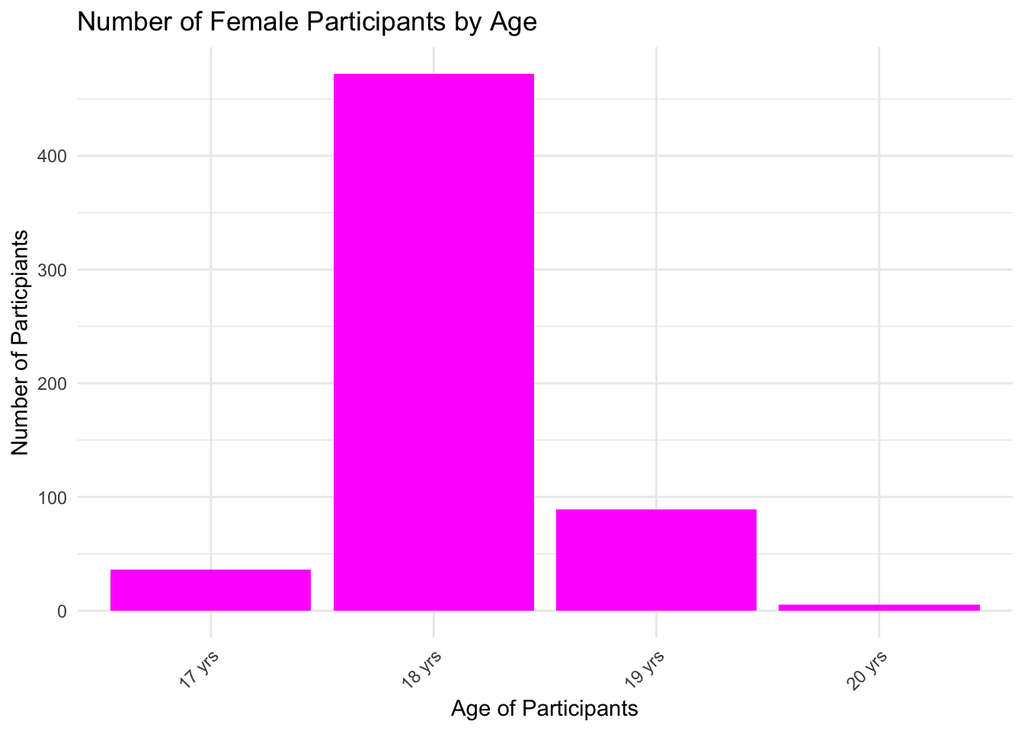

```r
act_all_female %>%
  ggplot(aes(dem1_01)) +
  geom_bar(fill = "magenta") +
  theme(axis.text.x = element_text(angle = 45, hjust = 1)) +
  labs(title = "Number of Female Participants by Age", y = "Number of Particpiants", x = "Age of Participants")
```

#### Distributions of BDI scores by age group. Distribution of BDI scores for 18-year-old female participants is positively skewed.

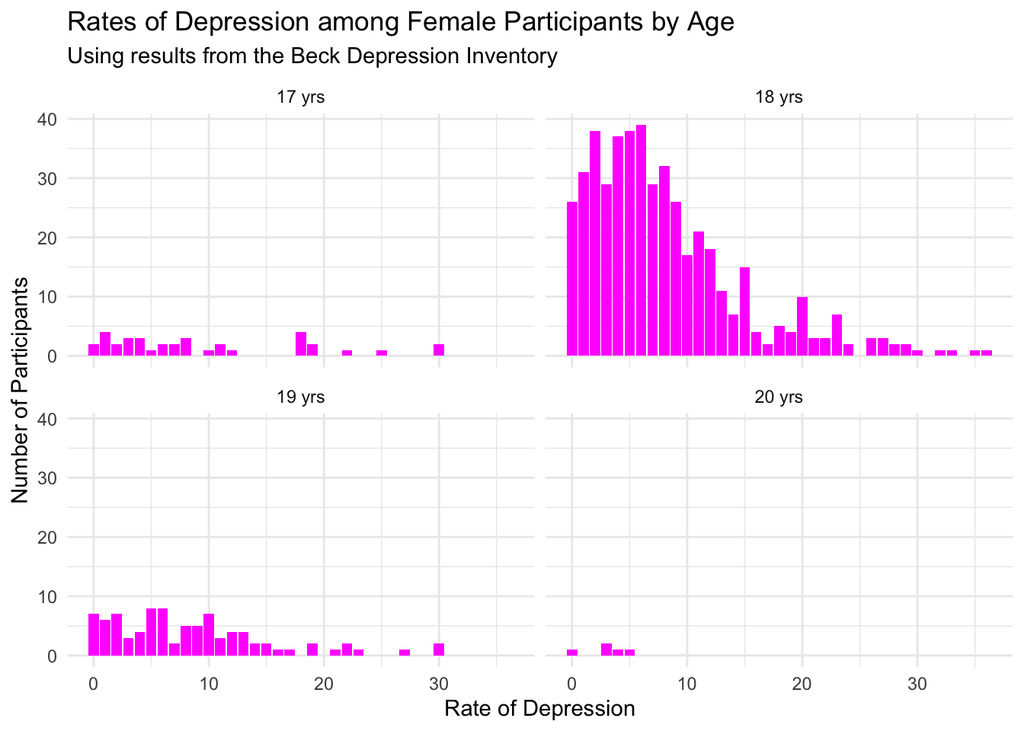

```r
act_all_female %>%
  ggplot(aes(bdi1)) +
  geom_bar(fill = "magenta") +
  facet_wrap(~dem1_01) +
  labs(title = "Rates of Depression among Female Participants by Age", subtitle = "Using results from the Beck Depression Inventory", y = "Number of Participants", x = "Rate of Depression")
```

#### Descriptive statistics of female participants’ BDI scores by age

```r
act_all_female %>%
  group_by(dem1_01) %>%
  summarize(mean_bdi = mean(bdi1, na.rm = TRUE),
            sd_bdi = sd(bdi1, na.rm = TRUE),
            n_bdi = n(),
            min_bdi = min(bdi1, na.rm = TRUE),
            max_bdi = max(bdi1, na.rm = TRUE))
```

```
## # A tibble: 4 × 6
##   dem1_01 mean_bdi sd_bdi n_bdi min_bdi max_bdi
##   <chr>      <dbl>  <dbl> <int>   <dbl>   <dbl>
## 1 17 yrs      9.58   8.59    36       0      30
## 2 18 yrs      8.07   6.73   472       0      36
## 3 19 yrs      8.40   6.88    89       0      30
## 4 20 yrs      3      1.87     5       0       5
```

#### Side-by-side boxplots of BDI scores by age for all female participants

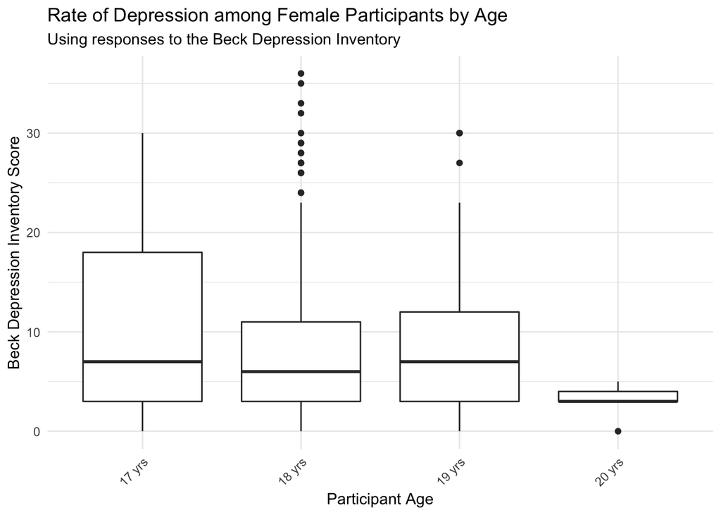

```r
ggplot(act_all_female, aes(bdi1, dem1_01)) +
  geom_boxplot() +
  coord_flip() +
  theme(axis.text.x = element_text(angle = 45, hjust = 1)) +
  labs(title = "Rate of Depression among Female Participants by Age", subtitle = "Using responses to the Beck Depression Inventory", x = "Beck Depression Inventory Score", y = "Participant Age" )
```

#### Bar chart of personal gross annual income for all female participants

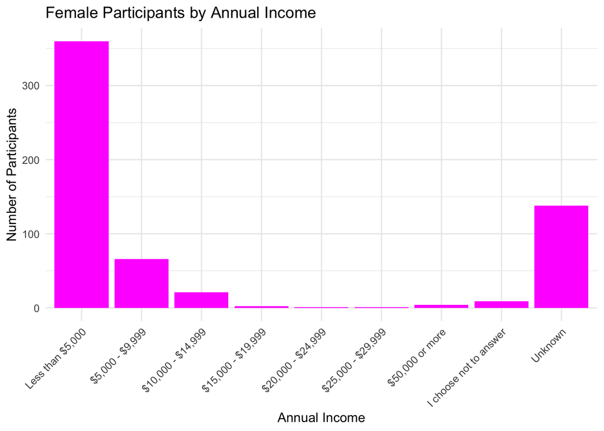

```r
act_all_female %>%
  mutate(dem1_14 = factor(dem1_14, levels = c("Less than $5,000",
                                              "$5,000 - $9,999",
                                              "$10,000 - $14,999",
                                              "$15,000 - $19,999",
                                              "$20,000 - $24,999",
                                              "$25,000 - $29,999",
                                              "$50,000 or more",
                                              "I choose not to answer",
                                              "Unknown"
                                              ))) %>%
  ggplot(aes(dem1_14)) +
  geom_bar(fill = "magenta") +
  theme(axis.text.x = element_text(angle = 45, hjust = 1)) +
  labs(title = "Female Participants by Annual Income", y = "Number of Participants", x = "Annual Income")
```

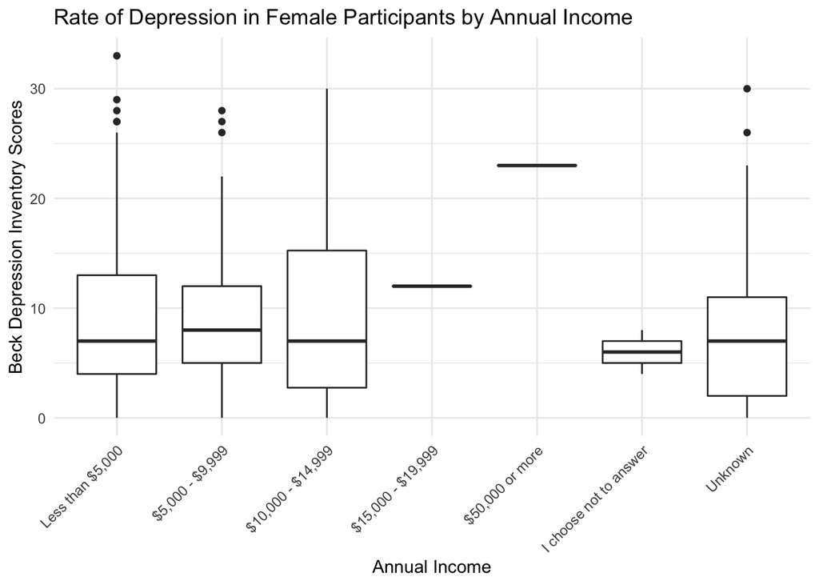

```r
act_all_female %>%
  filter(dem1_01 == "18" | dem1_15a == "Yes") %>%
  mutate(dem1_14 = factor(dem1_14, levels = c("Less than $5,000",
                                              "$5,000 - $9,999",
                                              "$10,000 - $14,999",
                                              "$15,000 - $19,999",
                                              "$20,000 - $24,999",
                                              "$25,000 - $29,999",
                                              "$50,000 or more",
                                              "I choose not to answer",
                                              "Unknown"
                                              ))) %>%
  ggplot(aes(bdi1, dem1_14)) +
  geom_boxplot() +
  coord_flip() +
  theme(axis.text.x = element_text(angle = 45, hjust = 1)) +
  labs(title = "Rate of Depression in Female Participants by Annual Income", x = "Beck Depression Inventory Scores", y = "Annual Income")
```

```r
act_all_female %>%
  filter(dem1_01 == "18" | dem1_15a == "Yes") %>%
  mutate(dem1_14 = factor(dem1_14, levels = c("Less than $5,000",
                                              "$5,000 - $9,999",
                                              "$10,000 - $14,999",
                                              "$15,000 - $19,999",
                                              "$20,000 - $24,999",
                                              "$25,000 - $29,999",
                                              "$50,000 or more",
                                              "I choose not to answer",
                                              "Unknown"
                                              ))) %>%
  group_by(dem1_14) %>%
  summarize(n = n(),
            M = round(mean(bdi1, na.rm = TRUE), 2),
            SD = round(sd(bdi1, na.rm = TRUE), 2),
            Min = min(bdi1, na.rm = TRUE),
            Max = max(bdi1, na.rm = TRUE)) %>%
  knitr::kable(col.names = c("Annual Income", "n", "M", "SD", "Min", "Max"), caption = "Descriptive Statistics of BDI Scores for 18-Year-Old Female Participants Currently Working")
```

| Annual Income | n | M | SD | Min | Max |
| --- | --- | --- | --- | --- | --- |
| Less than $5,000 | 122 | 9.17 | 7.74 | 0 | 33 |
| $5,000 - $9,999 | 40 | 9.70 | 7.25 | 0 | 28 |
| $10,000 - $14,999 | 16 | 9.44 | 8.59 | 0 | 30 |
| $15,000 - $19,999 | 1 | 12.00 | NA | 12 | 12 |
| $50,000 or more | 1 | 23.00 | NA | 23 | 23 |
| I choose not to answer | 3 | 6.00 | 2.00 | 4 | 8 |
| Unknown | 36 | 8.54 | 7.98 | 0 | 30 |

#### Trying out one of the table functions covered in Week 6 (gtsummary). The resulting table shows the counts and percentages of responses for each variable for female participants (e.g., number and percentage of female participants who reported their age as 17).

```r
act_all_female %>%
  gtsummary::tbl_summary()
```

| **Characteristic** | **N = 602**<sup>1</sup> |
| --- | --- |
| Study Identification Number from participant list | 23,370 (20,137, 35,262) |
| T1: Age |  |
| 17 yrs | 36 (6.0%) |
| 18 yrs | 472 (78%) |
| 19 yrs | 89 (15%) |
| 20 yrs | 5 (0.8%) |
| T1: Where do you live |  |
| In a dorm | 336 (56%) |
| In an apartment or house | 266 (44%) |
| T1: Where do you live: Dorm |  |
| I choose not to answer | 1 (0.3%) |
| In a dorm room with roommates | 327 (97%) |
| In a single dorm room | 8 (2.4%) |
| Unknown | 266 |
| T1: Where do you live: Apt or House |  |
| In an apartment/house alone | 4 (1.5%) |
| In an apartment/house with a boyfriend or girlfriend | 14 (5.3%) |
| In an apartment/house with roommates | 50 (19%) |
| With other family members | 23 (8.6%) |
| With your parents and siblings | 175 (66%) |
| Unknown | 336 |
| T1: Were you born in the US |  |
| I choose not to answer | 3 (0.5%) |
| No | 40 (6.6%) |
| Yes | 559 (93%) |
| T1: If no, what country |  |
|  | 562 (93%) |
| Addis Ababa, Ethiopia | 1 (0.2%) |
| Albania | 1 (0.2%) |
| Bangladesh | 2 (0.3%) |

[output cut: 1222 more lines]